```python
import pandas as pd
import numpy as np
import matplotlib.pyplot as plt
from tqdm import tqdm
```

```python
from sklearn.model_selection import train_test_split
```

```python
from IPython.display import display, Math
```

# Pobierz Dane & Preprocessing

```python
DATA_PATH = "dane_zad1.csv"
```

```python
df = pd.read_csv(DATA_PATH)
```

```python
df.head()
```

|  | A1 | A2 | A3 | A4 | A5 | A6 | A7 | A8 | A9 | A10 | D |
| --- | --- | --- | --- | --- | --- | --- | --- | --- | --- | --- | --- |
| 0 | 20.092091 | 1.673548 | 9.923381 | 7.687586 | 9.121323 | 20.711181 | 23.347262 | 14.398792 | 10.460684 | 4.623440 | 1 |
| 1 | 25.431807 | 5.625153 | 9.276870 | 27.683566 | 16.454241 | 13.341418 | 23.180162 | 10.874133 | 17.024978 | 20.599612 | 0 |
| 2 | 23.647011 | 26.013198 | 4.729723 | 5.588910 | 13.077481 | 20.830146 | 1.883304 | 14.135294 | 4.313362 | 18.542978 | 1 |
| 3 | 21.197763 | 25.533612 | 3.673269 | 1.915619 | 25.069512 | 2.425438 | 25.536494 | 13.139628 | 26.144889 | 25.730316 | 0 |
| 4 | 18.426135 | 11.545287 | 20.044614 | 15.834745 | 10.729403 | 20.854713 | 1.145791 | 21.510991 | 22.230372 | 0.611073 | 1 |

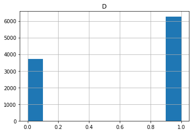

```python
df.hist(column="D");
```

Zbiór jest dość niezbalansowany, ale nie będę zajmował się tutaj resamplingiem.

```python
data = df.values
X, y = data[:, :-1], data[:,-1]
```

# Klasyfikatory

Zadanie polega na wyuczeniu poznanych klasyfikatorów (lista poniżej), przetestowaniu i dokonaniu oszacowania spodziewanego błędu klasyfikacji używając nierówności Hoeffdinga dla ewentualnych nowych przypadków.  
Celem jest osiągnięcie jak najlepszej jakości klasyfikacji (jak najniższy spodziewany błąd generalizacji).  
Należy to osiągnąć stosując metodę testowania za pomocą podziału próbki i dobierając właściwy rozmiar próbki testowej.  
Rozwiązując zadanie nie należy stosować kroswalidacji.  
W ramach zadania nie trzeba optymalizować wartości parametrów klasyfikatorów.

Lista poznanych klasyfikatorów:

> Naive Bayes;

> k-NN;

> Drzewo decyzyjne.

## Walidator

```python
def eps_value(alpha, test_size):
    return np.sqrt(-np.log(1 - alpha) / (2 * test_size))
```

```python
def err_plot(clf, alpha, k, to_cycle=5):
    bottom = 1/X.shape[0]
    dependency = []
    for test_freq in tqdm(np.linspace(bottom, 1-bottom, k+2)[1:-1]):
        upper_bound = 0
        for _ in range(to_cycle):
            x_train, x_test, y_train, y_test = train_test_split(X, y, test_size=test_freq)
            sk_nb = clf.fit(x_train, y_train)
            upper_bound += 1-sk_nb.score(x_test, y_test) + eps_value(alpha, y_test.shape[0])
        dependency.append((y_test.shape[0], upper_bound/to_cycle))

    dependency = np.array(dependency)
    upped_bound_idx = np.argmin(dependency[:, 1])
    test_size = dependency[upped_bound_idx, 0]
    ge_upper_bound = dependency[upped_bound_idx, 1]
    plt.grid(True)
    plt.xlabel("test_size")
    plt.ylabel("empirical_error + epsilon_value")
    plt.scatter(dependency[upped_bound_idx, 0], dependency[upped_bound_idx, 1], c="k")
    plt.plot(dependency[:,0], dependency[:,1], )

    return int(test_size), eps_value(alpha, test_size), ge_upper_bound
```

## Naive Bayes

```python
from sklearn.naive_bayes import GaussianNB
```

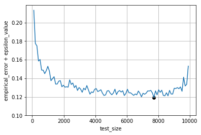

```python
test_size1, eps_value1, upper_bound1 = err_plot(clf=GaussianNB(), alpha=0.9, k=100)
```

```python
display(Math(r'|T|: {} \\ \epsilon: {:.4f} \\ Błąd\ empiryczny: {:.4f} \\ Najmniejsze\ napotkane\ oszacowanie\ błędu\ generalizacji: {:.4f}'\
             .format(test_size1, eps_value1, upper_bound1-eps_value1, upper_bound1)))
```

$\displaystyle |T|: 7723 \\ \epsilon: 0.0122 \\ Błąd\ empiryczny: 0.1072 \\ Najmniejsze\ napotkane\ oszacowanie\ błędu\ generalizacji: 0.1194$

Użyte zostały defaultowe parametry:

```python
GaussianNB().get_params()
```

```
{'priors': None, 'var_smoothing': 1e-09}
```

## k-NN

```python
from sklearn.neighbors import KNeighborsClassifier
```

$\displaystyle k: 2 \\ |T|: 3070 \\ \epsilon: 0.0194 \\ Błąd\ empiryczny: 0.1560 \\ Najmniejsze\ napotkane\ oszacowanie\ błędu\ generalizacji: 0.1753$

$\displaystyle k: 5 \\ |T|: 3466 \\ \epsilon: 0.0182 \\ Błąd\ empiryczny: 0.1091 \\ Najmniejsze\ napotkane\ oszacowanie\ błędu\ generalizacji: 0.1273$

$\displaystyle k: 8 \\ |T|: 3367 \\ \epsilon: 0.0185 \\ Błąd\ empiryczny: 0.0975 \\ Najmniejsze\ napotkane\ oszacowanie\ błędu\ generalizacji: 0.1160$

$\displaystyle k: 11 \\ |T|: 2575 \\ \epsilon: 0.0211 \\ Błąd\ empiryczny: 0.0918 \\ Najmniejsze\ napotkane\ oszacowanie\ błędu\ generalizacji: 0.1130$

$\displaystyle k: 14 \\ |T|: 4060 \\ \epsilon: 0.0168 \\ Błąd\ empiryczny: 0.0881 \\ Najmniejsze\ napotkane\ oszacowanie\ błędu\ generalizacji: 0.1050$

$\displaystyle k: 17 \\ |T|: 5050 \\ \epsilon: 0.0151 \\ Błąd\ empiryczny: 0.0914 \\ Najmniejsze\ napotkane\ oszacowanie\ błędu\ generalizacji: 0.1065$

$\displaystyle k: 20 \\ |T|: 3565 \\ \epsilon: 0.0180 \\ Błąd\ empiryczny: 0.0843 \\ Najmniejsze\ napotkane\ oszacowanie\ błędu\ generalizacji: 0.1022$

$\displaystyle k: 23 \\ |T|: 3664 \\ \epsilon: 0.0177 \\ Błąd\ empiryczny: 0.0876 \\ Najmniejsze\ napotkane\ oszacowanie\ błędu\ generalizacji: 0.1053$

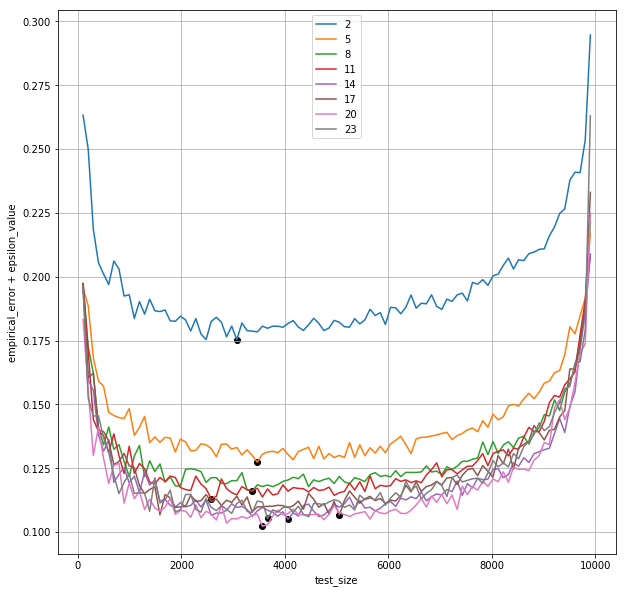

```python
plt.figure(figsize=(10, 10))
for nbn in range(2, 25, 3):
    test_size2, eps_value2, upper_bound2 = err_plot(clf=KNeighborsClassifier(n_neighbors=nbn), alpha=0.9, k=100)
    display(Math(r'k: {} \\ |T|: {} \\ \epsilon: {:.4f} \\ Błąd\ empiryczny: {:.4f} \\ Najmniejsze\ napotkane\ oszacowanie\ błędu\ generalizacji: {:.4f}'\
             .format(nbn, test_size2, eps_value2, upper_bound2-eps_value2, upper_bound2)))
plt.legend(range(2, 25, 3));
```

Użyte zostały defaultowe parametry, oprócz iterowanej liczby sąsiadów względem których podejmowana jest decyzja:

```python
KNeighborsClassifier().get_params()
```

```
{'algorithm': 'auto',
 'leaf_size': 30,
 'metric': 'minkowski',
 'metric_params': None,
 'n_jobs': None,
 'n_neighbors': 5,
 'p': 2,
 'weights': 'uniform'}
```

## Drzewo decyzyjne

```python
from sklearn.tree import DecisionTreeClassifier
```

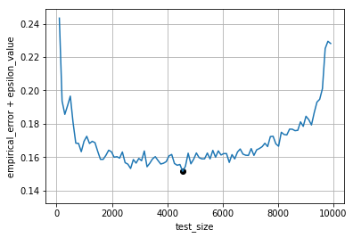

```python
test_size3, eps_value3, upper_bound3 = err_plot(clf=DecisionTreeClassifier(), alpha=0.9, k=100)
```

```python
display(Math(r'|T|: {} \\ \epsilon: {:.4f} \\ Błąd\ empiryczny: {:.4f} \\ Najmniejsze\ napotkane\ oszacowanie\ błędu\ generalizacji: {:.4f}'\
             .format(test_size3, eps_value3, upper_bound3-eps_value3, upper_bound3)))
```

$\displaystyle |T|: 4555 \\ \epsilon: 0.0159 \\ Błąd\ empiryczny: 0.1356 \\ Najmniejsze\ napotkane\ oszacowanie\ błędu\ generalizacji: 0.1515$

Użyte zostały defaultowe parametry:

```python
DecisionTreeClassifier().get_params()
```

```
{'class_weight': None,
 'criterion': 'gini',
 'max_depth': None,
 'max_features': None,
 'max_leaf_nodes': None,
 'min_impurity_decrease': 0.0,
 'min_impurity_split': None,
 'min_samples_leaf': 1,
 'min_samples_split': 2,
 'min_weight_fraction_leaf': 0.0,
 'presort': False,
 'random_state': None,
 'splitter': 'best'}
```

# Wnioski

Przy braku przeszukiwania przestrzeni hiperparametrów, badanych modeli, najlepsze wyniki uzyskał klasyfikator $k-NN$, przy $k=20$.  
Wyżej można przypatrzeć się wynikom tego modelu.